# Analysis-of-Suicide-Trends-Globally-in-R

Installing Packages

```r
install.packages("ggalt")
install.packages("countrycode")
install.packages("rworldmap")
install.packages("gridExtra")
install.packages("broom")
install.packages("magrittr")
```

```r
library(tidyverse)
library(ggalt)
library(countrycode)
library(rworldmap)
library(gridExtra)
library(broom)
library(readr)
library(magrittr)
```

Data Import

```r
 Country_df<- read_csv("https://raw.githubusercontent.com/Abhidubey96/Analysis-of-Suicide-Trends-Globally-in-R/main/Country%20Data.csv")
 Suicide_df <- read_csv("https://raw.githubusercontent.com/Abhidubey96/Analysis-of-Suicide-Trends-Globally-in-R/main/Suicide%20Data%20by%20Country.csv")
```

View Data

```r
View(Country_df)
View(Suicide_df)
```

Merging Both 2 files

```r
df <- cbind(Suicide_df, Country_df)

View(df)
```

CLeaning and Wrangling of data

```r
summary(df)
```

```
   country               year          sex                age
 Length:27820       Min.   :1985   Length:27820       Length:27820
 Class :character   1st Qu.:1995   Class :character   Class :character
 Mode  :character   Median :2002   Mode  :character   Mode  :character
                    Mean   :2001
                    3rd Qu.:2008
                    Max.   :2016

  suicides_no        population       suicides/100k pop country-year
 Min.   :    0.0   Min.   :     278   Min.   :  0.00    Length:27820
 1st Qu.:    3.0   1st Qu.:   97498   1st Qu.:  0.92    Class :character
 Median :   25.0   Median :  430150   Median :  5.99    Mode  :character
 Mean   :  242.6   Mean   : 1844794   Mean   : 12.82
 3rd Qu.:  131.0   3rd Qu.: 1486143   3rd Qu.: 16.62
 Max.   :22338.0   Max.   :43805214   Max.   :224.97

  HDI for year   gdp_for_year ($)    gdp_per_capita ($)  generation
 Min.   :0.483   Min.   :4.692e+07   Min.   :   251     Length:27820
 1st Qu.:0.713   1st Qu.:8.985e+09   1st Qu.:  3447     Class :character
 Median :0.779   Median :4.811e+10   Median :  9372     Mode  :character
 Mean   :0.777   Mean   :4.456e+11   Mean   : 16866
 3rd Qu.:0.855   3rd Qu.:2.602e+11   3rd Qu.: 24874
 Max.   :0.944   Max.   :1.812e+13   Max.   :126352
 NA's   :19456
```

```r
str(df)
```

```
'data.frame':   27820 obs. of  12 variables:
 $ country           : chr  "Albania" "Albania" "Albania" "Albania" ...
 $ year              : num  1987 1987 1987 1987 1987 ...
 $ sex               : chr  "male" "male" "female" "male" ...
 $ age               : chr  "15-24 years" "35-54 years" "15-24 years" "75+ years" ...
 $ suicides_no       : num  21 16 14 1 9 1 6 4 1 0 ...
 $ population        : num  312900 308000 289700 21800 274300 ...
 $ suicides/100k pop : num  6.71 5.19 4.83 4.59 3.28 2.81 2.15 1.56 0.73 0 ...
 $ country-year      : chr  "Albania1987" "Albania1987" "Albania1987" "Albania1987" ...
 $ HDI for year      : num  NA NA NA NA NA NA NA NA NA NA ...
 $ gdp_for_year ($)  : num  2.16e+09 2.16e+09 2.16e+09 2.16e+09 2.16e+09 ...
 $ gdp_per_capita ($): num  796 796 796 796 796 796 796 796 796 796 ...
 $ generation        : chr  "Generation X" "Silent" "Generation X" "G.I. Generation" ...
```

```r
# Removing unnecessary columns
# Renaming the variable names
df <- df %>%
  select(-c(`HDI for year`, `suicides/100k pop`)) %>%
  rename(gdp_per_year = `gdp_for_year ($)`,
         gdp_per_capita = `gdp_per_capita ($)`,
         country_year = `country-year`) %>%
  as.data.frame()

View(df)
str(df)
```

```
'data.frame':   27820 obs. of  10 variables:
 $ country       : chr  "Albania" "Albania" "Albania" "Albania" ...
 $ year          : num  1987 1987 1987 1987 1987 ...
 $ sex           : chr  "male" "male" "female" "male" ...
 $ age           : chr  "15-24 years" "35-54 years" "15-24 years" "75+ years" ...
 $ suicides_no   : num  21 16 14 1 9 1 6 4 1 0 ...
 $ population    : num  312900 308000 289700 21800 274300 ...
 $ country_year  : chr  "Albania1987" "Albania1987" "Albania1987" "Albania1987" ...
 $ gdp_per_year  : num  2.16e+09 2.16e+09 2.16e+09 2.16e+09 2.16e+09 ...
 $ gdp_per_capita: num  796 796 796 796 796 796 796 796 796 796 ...
 $ generation    : chr  "Generation X" "Silent" "Generation X" "G.I. Generation" ...
```

Extensive Cleaning and Wrangling in Data

```r
# data is missing for 2016 year for many countries
# every country should have 12 observations based upon the age and gender. But Data for 2016 shows less entries. Also some countries are missing totally.
# So its better to remove it from data frame df
df <- df %>%
  filter(year != 2016) %>%
  select(-country_year)

# So now we have only data from 1985 to 2015
View(df)

# Making Continent variable by using country code library
df$continent <- countrycode(sourcevar = df[, "country"],
                              origin = "country.name",
                              destination = "continent")

View(df)

#Changing Data type for variables age and generation and making them ordinal by using factor function

df$age <- factor(df$age, ordered = T,
                   levels = c("5-14 years",
                              "15-24 years",
                              "25-34 years",
                              "35-54 years",
                              "55-74 years",
                              "75+ years"))

df$generation <- factor(df$generation,
                   ordered = T,
                   levels = c("G.I. Generation",
                              "Silent",
                              "Boomers",
                              "Generation X",
                              "Millenials",
                              "Generation Z"))

# Global suicide rate over time
Global <- (sum(as.numeric(df$suicides_no)) / sum(as.numeric(df$population))) * 100000

View(df)

summary(df)
```

```
   country               year          sex                     age
 Length:27660       Min.   :1985   Length:27660       5-14 years :4610
 Class :character   1st Qu.:1994   Class :character   15-24 years:4610
 Mode  :character   Median :2002   Mode  :character   25-34 years:4610
                    Mean   :2001                      35-54 years:4610
                    3rd Qu.:2008                      55-74 years:4610
                    Max.   :2015                      75+ years  :4610
  suicides_no        population        gdp_per_year       gdp_per_capita
 Min.   :    0.0   Min.   :     278   Min.   :4.692e+07   Min.   :   251
 1st Qu.:    3.0   1st Qu.:   97535   1st Qu.:8.976e+09   1st Qu.:  3436
 Median :   25.0   Median :  430725   Median :4.801e+10   Median :  9283
 Mean   :  243.4   Mean   : 1850689   Mean   :4.471e+11   Mean   : 16816
 3rd Qu.:  132.0   3rd Qu.: 1491041   3rd Qu.:2.602e+11   3rd Qu.: 24796
 Max.   :22338.0   Max.   :43805214   Max.   :1.812e+13   Max.   :126352
           generation    continent
 G.I. Generation:2744   Length:27660
 Silent         :6332   Class :character
 Boomers        :4958   Mode  :character
 Generation X   :6376
 Millenials     :5780
 Generation Z   :1470
```

```r
glimpse(df)
```

```
Rows: 27,660
Columns: 10
$ country        <chr> "Albania", "Albania", "Albania", "Albania", "Albania"...
$ year           <dbl> 1987, 1987, 1987, 1987, 1987, 1987, 1987, 1987, 1987,...
$ sex            <chr> "male", "male", "female", "male", "male", "female", "...
$ age            <ord> 15-24 years, 35-54 years, 15-24 years, 75+ years, 25-...
$ suicides_no    <dbl> 21, 16, 14, 1, 9, 1, 6, 4, 1, 0, 0, 0, 2, 17, 1, 14, ...
$ population     <dbl> 312900, 308000, 289700, 21800, 274300, 35600, 278800,...
$ gdp_per_year   <dbl> 2156624900, 2156624900, 2156624900, 2156624900, 21566...
$ gdp_per_capita <dbl> 796, 796, 796, 796, 796, 796, 796, 796, 796, 796, 796...
$ generation     <ord> Generation X, Silent, Generation X, G.I. Generation, ...
$ continent      <chr> "Europe", "Europe", "Europe", "Europe", "Europe", "Eu...
```

```r
# Now our Data Frame is cleaned and ready for visualizations
```

Visualization 1 Heat Map of suicide cases globally

Iteration 1 This cell will lot of time because suicides no entries are more, better to comment this cell.

```r
mapdata <- joinCountryData2Map(df, joinCode = "NAME", nameJoinColumn = "country")
```

```
27348 codes from your data successfully matched countries in the map
312 codes from your data failed to match with a country code in the map
145 codes from the map weren't represented in your data
```

```
You asked for 7 categories, 5 were used due to pretty() classification
```

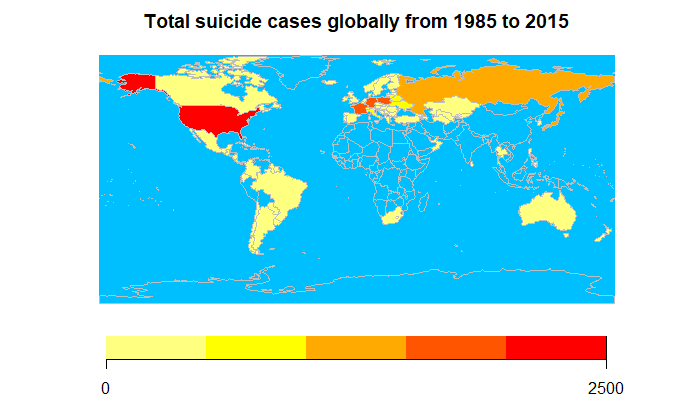

```r
mapCountryData(mapdata,
nameColumnToPlot="suicides_no",
colourPalette = "heat",
mapTitle="Total suicide cases globally from 1985 to 2015",
mapRegion = "world",
oceanCol="deepskyblue",
catMethod = "pretty")
```

Iteration 2 Adding suicide per 100k population

```r
region <- df %>%
  group_by(country) %>%
  summarize(suicide_per_100k = (sum(as.numeric(suicides_no)) / sum(as.numeric(population))) * 100000)
countrydata1 <- joinCountryData2Map(region, joinCode = "NAME", nameJoinColumn = "country")
```

```
98 codes from your data successfully matched countries in the map
2 codes from your data failed to match with a country code in the map
145 codes from the map weren't represented in your data
```

```
You asked for 7 categories, 9 were used due to pretty() classification
```

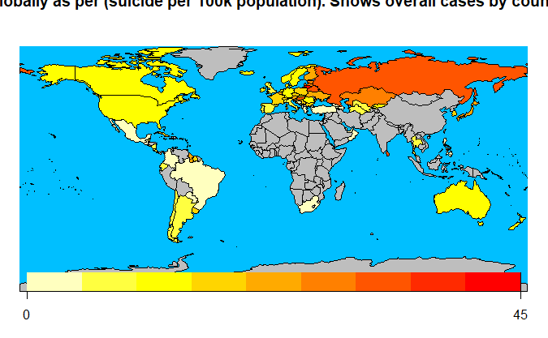

```r
par(mar=c(0, 0, 0, 0)) # margins


mapCountryData(countrydata1,
nameColumnToPlot="suicide_per_100k",
colourPalette = "heat",
mapTitle="Total suicide cases globally as per (suicide per 100k population). Shows overall cases by country from 1985 to 2015",
mapRegion = "world",
oceanCol="deepskyblue",
missingCountryCol="gray",
borderCol = "black",
catMethod = "pretty")
```

Visualizing suicide cases for america and europe

```r
region <- df %>%
  group_by(country) %>%
  summarize(suicide_per_100k = (sum(as.numeric(suicides_no)) / sum(as.numeric(population))) * 100000)
countrydata <- joinCountryData2Map(region, joinCode = "NAME", nameJoinColumn = "country")
```

```
98 codes from your data successfully matched countries in the map
2 codes from your data failed to match with a country code in the map
145 codes from the map weren't represented in your data
```

```
You asked for 7 categories, 9 were used due to pretty() classification
```

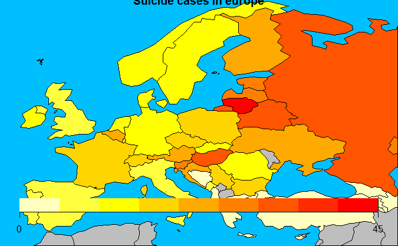

```r
par(mar=c(0, 0, 0, 0)) # margins
mapCountryData(countrydata,
nameColumnToPlot="suicide_per_100k",
mapTitle="Suicide cases in europe",
mapRegion = "europe",
oceanCol="deepskyblue",
missingCountryCol="gray",
borderCol = "black",
catMethod = "pretty")
```

```
You asked for 7 categories, 9 were used due to pretty() classification
```

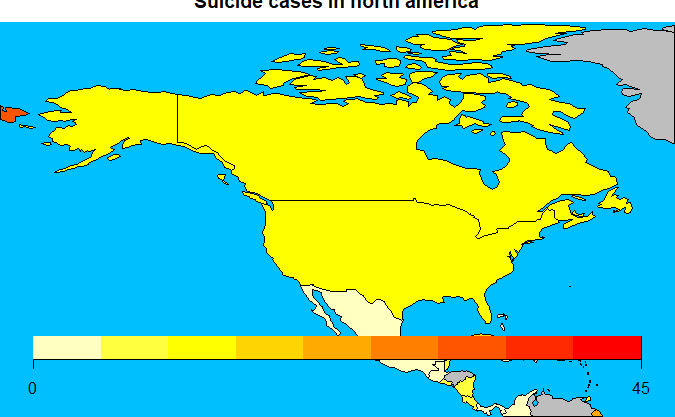

```r
mapCountryData(countrydata,
nameColumnToPlot="suicide_per_100k",
mapTitle="Suicide cases in north america",
mapRegion = "north america",
oceanCol="deepskyblue",
missingCountryCol="gray",
borderCol = "black",
catMethod = "pretty")
```

Visualization 2

What is the relation between age and generation over years from 1985 to 2015 suicide cases per 100k population? Is it True that new generation suicide cases globally are growing rapidly?

To Answer above question, we will follow below iterations

visualization for age varibale

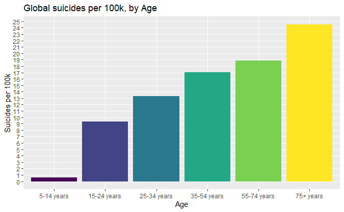

```r
df %>%
  group_by(age) %>%
  summarize(suicide_per_100k = (sum(as.numeric(suicides_no)) / sum(as.numeric(population))) * 100000) %>%
  ggplot(aes(x = age, y = suicide_per_100k, fill = age)) +
  geom_bar(stat = "identity") +
  labs(title = "Global suicides per 100k, by Age",
       x = "Age",
       y = "Suicides per 100k") +
  theme(legend.position = "none") +
  scale_y_continuous(breaks = seq(0, 30, 1), minor_breaks = F)
```

visualization of generation variable

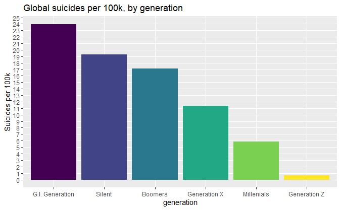

```r
df %>%
  group_by(generation) %>%
  summarize(suicide_per_100k = (sum(as.numeric(suicides_no)) / sum(as.numeric(population))) * 100000) %>%
  ggplot(aes(x = generation, y = suicide_per_100k, fill = generation)) +
  geom_bar(stat = "identity") +
  labs(title = "Global suicides per 100k, by generation",
       x = "generation",
       y = "Suicides per 100k") +
  theme(legend.position = "none") +
  scale_y_continuous(breaks = seq(0, 30, 1), minor_breaks = F)
```

final visualization by merging 1st and 2 nd visualization of age and generation. plotting them with year ( over time )

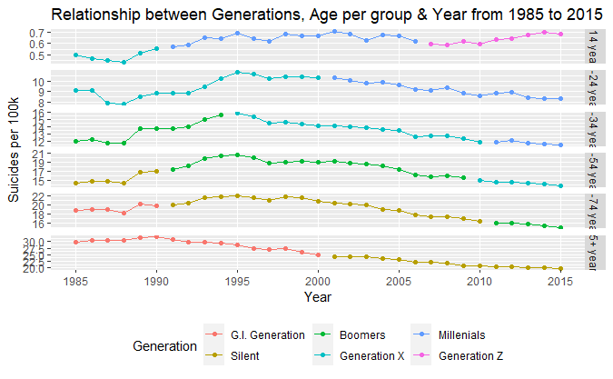

```r
df %>%
  group_by(generation, age, year) %>%
  summarize(suicide_per_100k = (sum(as.numeric(suicides_no)) / sum(as.numeric(population))) * 100000) %>%
  ggplot(aes(x = year, y = suicide_per_100k, col = factor(generation, ordered = F))) +
  geom_point() +
  geom_line() +
  facet_grid(age ~ ., scales = "free_y") +
  scale_x_continuous(breaks = seq(1985, 2015, 5), minor_breaks = NULL) +
  labs(title = "Relationship between Generations, Age per group & Year from 1985 to 2015",
       x = "Year",
       y = "Suicides per 100k",
       col = "Generation") +
  theme(legend.position = "bottom")
```

Visualization 3

What is the global trend of suicide cases per 100k population from 1985 to 2015?

If we talk about some specific countries from Europe and North America what’s the trend?

Iteration 1

Analyzing countries with high gdp per capita income

```r
library(sqldf)

gdp_df <-sqldf("select country, sum(gdp_per_capita) as gdp from df group by country")
gdp_df
```

| country | gdp |
| --- | --- |
| Albania | 490788 |
| Antigua and Barbuda | 3385212 |
| Argentina | 2944044 |
| Armenia | 520548 |
| Aruba | 4069236 |
| Australia | 11799504 |
| Austria | 12618240 |
| Azerbaijan | 192984 |
| Bahamas | 7130844 |
| Bahrain | 4545960 |

[output cut: 90 more lines]

```r
# finding 5 countries with max gdp per capita income

gdp_df1 <-sqldf("select country, gdp from gdp_df where gdp > 14300000")
gdp_df1
```

| country | gdp |
| --- | --- |
| Iceland | 14355876 |
| Luxembourg | 25593000 |
| Norway | 20635056 |
| Switzerland | 15871404 |
| United States | 14608296 |

```r
NA
```

Plotting

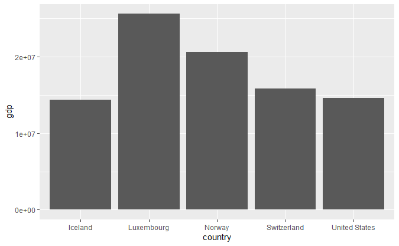

```r
ggplot(data=gdp_df1, aes(x= country, y=gdp)) +
geom_bar(stat="identity")
```

Iteration 2

Checking Visualization suicide trend over time For all Countries

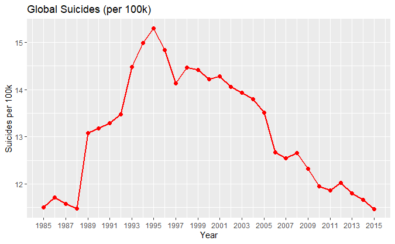

```r
df %>%
  group_by(year) %>%
  summarize(population = sum(population),
            suicides = sum(suicides_no),
            suicides_per_100k = (suicides / population) * 100000) %>%
  ggplot(aes(x = year, y = suicides_per_100k)) +
  geom_line(col = "red", size = 1) +
  geom_point(col = "red", size = 2) +
  labs(title = "Global Suicides (per 100k)",
       x = "Year",
       y = "Suicides per 100k") +
  scale_x_continuous(breaks = seq(1985, 2015, 2)) +
  scale_y_continuous(breaks = seq(10, 20))
```

Iteration 3

HIGH GDP countries trend of suicide cases over time Checking suicide cases for specific countries

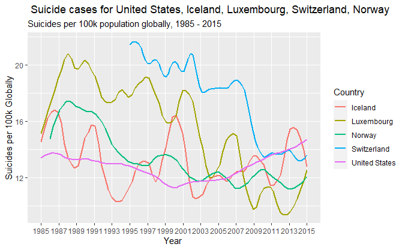

```r
df_specific <- df %>%
  filter(country %in% c("Iceland",
                        "Luxembourg",
                        "Norway",
                        "Switzerland",
                        "United States"))

df_specific %>%
  group_by(country, year) %>%
  summarize(suicide_per_100k = (sum(as.numeric(suicides_no)) / sum(as.numeric(population))) * 100000) %>%
  ggplot(aes(x = year, y = suicide_per_100k, col = country)) +
  geom_smooth(se = F, span = 0.2) +
  scale_x_continuous(breaks = seq(1985, 2015, 2), minor_breaks = F) +
  labs(title = " Suicide cases for United States, Iceland, Luxembourg, Switzerland, Norway",
       subtitle = "Suicides per 100k population globally, 1985 - 2015",
       x = "Year ",
       y = "Suicides per 100k Globally",
       col = "Country")
```